# Workforce Journey Exploratory Data Analysis

Bill Prisbrey

2025-06-19

**PURPOSE:** The purpose of this report is to describe the “workforce journey” data and highlight possible inconsistencies for further clarification with HR.

**OBJECTIVES:**

1. Describe the “Workforce Journey” data.
2. Define “boundary” actions and check for internal consistency.

**EXECUTIVE SUMMARY:**

The “workforce journey” data is examined. Some 2,456,407 rows use 17 distinct actions to describe the employment experience of 158,369 employees since 2010.

Of particular interest are the so-called “boundary actions” that define entry and exit into the workforce. These include “primary” actions like hiring and retiring; “break” actions that describe a “short work break”; and “leave” actions for long term disability or a paid leave of absence.

When these boundary actions are so simply defined, there are inconsistencies in the respective tallies. These need to be clarified with HR.

Possible improvements and points for additional clarity include:

- Anchor the age bands to a specific date rather than the time of the query.
- Clarify the actions and reasons that define boundary entry and exits.
- Clarify the fields “EMPL_RCD” and “EFFSEQ”.
- Clarify edge cases and complex cases (like the employment history of “00028073” and the records of “00029479” on EFFDT == “2011-07-16”).
- Review the defintion of “voluntary” vs “involuntary” termination and discuss specific case.

**SUMMARY:**

2,456,407 rows covering dates between 2010-01-02 and 2027-03-15 are queried.

One row with a bad date (“2202-11-21”) is filtered out.

The remaining data describes 158,369 employees and every employment “action” that defines their experience (such as transfers, pay raises, leave of absence, and eventual termination or retirement.) 17 distinct actions are further explained with 105 unique “action reasons.” Employees have a median count of 9 of these “actions” in their employment history. (At an extreme, one employee (00028073) has 449 actions.)

Overwhelmingly, an action of “Data Change” (“DTA”) is the most common, followed by “Pay Rate Change” (“PAY”) and distantly “Termination” (“TER”), “Hire” (“HIR”), and “Transfer” (“XFR”). The “Termination” (“TER”) action has the most “action reasons” (43).

An age band of the employee is provided of the decade of their age at the time of the query. Each employee has one un-changing age band. The most frequent band is the decade of the thirties.

Termination is almost exclusively flagged as “voluntary”, with only 3.3% of the flagged rows described as “involuntary.”

A strong seasonal spike in actions is seen around July 1st. A consistent bi-weekly pattern in actions is also noted.

Boundary actions are defined as actions that signify entering or leaving the workforce. This includes “primary” actions of hire or rehire, and terminate or retire; “break” actions of a “short work break”; and “leave” actions of paid leave of absence, leave of absence, or long-term disability and “return from leave.”

These are tallied per employee and found to have inconsistent results, where an employee has “exited” the workforce without a prior “entry” action, for example. This appears to be due to:  
(1) simplistic definitions of boundary actions (for example, “rehire” could be ignored if “Hire Concurrent Job” is the supplied action reason)  
(2) incomplete understanding of the use of the “EMPL_RCD” field causing duplication that needs to be managed  
(3) complicated dates where multiple actions are entered that may be contradictory

## (1) DESCRIBE THE WORKFORCE JOURNEY DATA

### Data summary

Data summary

| Name | journeyData |
| --- | --- |
| Number of rows | 2456406 |
| Number of columns | 12 |
| _______________________ |  |
| Column type frequency: |  |
| character | 8 |
| factor | 1 |
| numeric | 2 |
| POSIXct | 1 |
| ________________________ |  |
| Group variables | None |

**Variable type: character**

| skim_variable | n_missing | complete_rate | min | max | empty | n_unique | whitespace |
| --- | --- | --- | --- | --- | --- | --- | --- |
| ACTION | 0 | 1.00 | 3 | 3 | 0 | 17 | 0 |
| EMPLID | 0 | 1.00 | 8 | 8 | 0 | 158369 | 0 |
| ACTION_DESCR | 0 | 1.00 | 4 | 22 | 0 | 17 | 0 |
| ACTION_REASON | 0 | 1.00 | 2 | 3 | 0 | 105 | 0 |
| ACTION_REASON_DESCR | 0 | 1.00 | 5 | 30 | 0 | 110 | 0 |
| VOLUNTARY_FLAG | 2260112 | 0.08 | 9 | 11 | 0 | 2 | 0 |
| boundary | 1845746 | 0.25 | 4 | 5 | 0 | 2 | 0 |
| boundary_type | 1845746 | 0.25 | 5 | 7 | 0 | 3 | 0 |

**Variable type: factor**

| skim_variable | n_missing | complete_rate | ordered | n_unique | top_counts |
| --- | --- | --- | --- | --- | --- |
| AGE_BAND | 0 | 1 | FALSE | 9 | 30s: 736870, 40s: 560823, 20s: 431974, 50s: 326741 |

**Variable type: numeric**

| skim_variable | n_missing | complete_rate | mean | sd | p0 | p25 | p50 | p75 | p100 | hist |
| --- | --- | --- | --- | --- | --- | --- | --- | --- | --- | --- |
| EMPL_RCD | 0 | 1 | 0.2 | 0.55 | 0 | 0 | 0 | 0 | 12 | ▇▁▁▁▁ |
| EFFSEQ | 0 | 1 | 0.2 | 0.49 | 0 | 0 | 0 | 0 | 30 | ▇▁▁▁▁ |

**Variable type: POSIXct**

| skim_variable | n_missing | complete_rate | min | max | median | n_unique |
| --- | --- | --- | --- | --- | --- | --- |
| EFFDT | 0 | 1 | 2010-01-02 | 2027-03-15 | 2018-08-31 | 5724 |

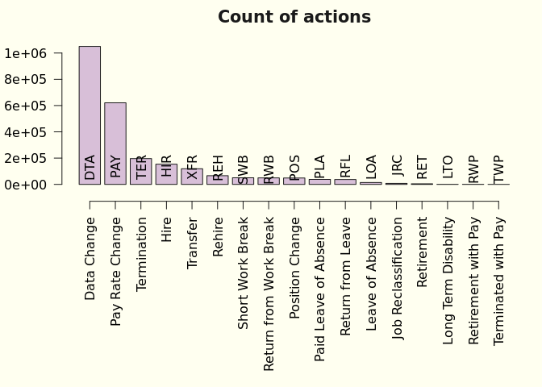

Actions and unique associated reasons

|  | description | count | unique reasons |
| --- | --- | --- | --- |
| DTA | Data Change | 1050045 | 16 |
| HIR | Hire | 153675 | 2 |
| JRC | Job Reclassification | 7498 | 2 |
| LOA | Leave of Absence | 14371 | 15 |
| LTO | Long Term Disability | 481 | 1 |
| PAY | Pay Rate Change | 620868 | 11 |
| PLA | Paid Leave of Absence | 38005 | 17 |
| POS | Position Change | 48522 | 3 |
| REH | Rehire | 66313 | 2 |
| RET | Retirement | 4304 | 5 |
| RFL | Return from Leave | 37023 | 3 |
| RWB | Return from Work Break | 49321 | 1 |
| RWP | Retirement with Pay | 433 | 3 |
| SWB | Short Work Break | 50440 | 2 |
| TER | Termination | 196294 | 43 |
| TWP | Terminated with Pay | 1 | 1 |
| XFR | Transfer | 118812 | 8 |

Action reasons

|  | description | count |
| --- | --- | --- |
| 30D | 30 Day | 147 |
| 90D | 90 Day | 56 |
| ADJ | Adjustment | 104486 |
| AML | Administrative Leave | 178 |
| ASN | Termination of Assignment | 12120 |
| BAC | BA Conversion (SYS) | 32107 |
| BEC | Ben Elig Change (SYS) | 52959 |
| BNK | Employer Bankruptcy | 1 |
| CDP | Correction-Department | 824 |
| CJC | Correction-Job Code | 869 |
| CNT | Contract (SYS) | 6561 |
| COV | COVID-19 | 1453 |
| CPR | Correction-Pay Rate | 47 |
| CRP | Duplicate EE Record | 83 |
| DEA | Death | 1245 |
| DEV | Development Opportunities | 104 |
| DST | Distribution Change (SYS) | 522716 |
| EAC | End Employment Agreement | 485 |
| EES | Fellow Employee | 5 |
| EMT | Emeritus | 700 |
| ERT | Early Retirement | 287 |
| EVW | E-Verify Withdrawal | 29 |
| EXT | Extension | 2023 |
| FAM | Family Reasons | 151 |
| FCA | FICA Status Change (SYS) | 188376 |
| FLS | Pay Adj - FLSA Reg(SYS) | 582 |
| FML | Family and Medical Leave Act | 38774 |
| FTE | FTE Change | 1081 |
| FUR | Furlough | 450 |
| FYA | FYSC Auto Term (SYS) | 8 |

[output cut: 82 more lines]

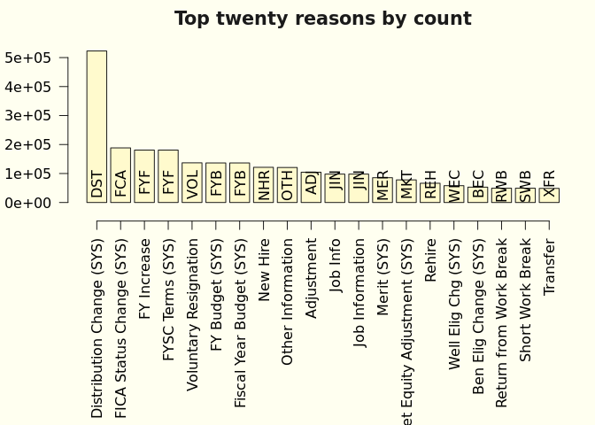

Actions and reasons

|  | action | reason | description | count |
| --- | --- | --- | --- | --- |
| DTA | Data Change | BAC | BA Conversion (SYS) | 32107 |
| DTA | Data Change | BEC | Ben Elig Change (SYS) | 52959 |
| DTA | Data Change | CNT | Contract (SYS) | 6561 |
| DTA | Data Change | CDP | Correction-Department | 824 |
| DTA | Data Change | CJC | Correction-Job Code | 869 |
| DTA | Data Change | CPR | Correction-Pay Rate | 47 |
| DTA | Data Change | DST | Distribution Change (SYS) | 522716 |
| DTA | Data Change | EMT | Emeritus | 5 |
| DTA | Data Change | FCA | FICA Status Change (SYS) | 188376 |
| DTA | Data Change | FTE | FTE Change | 748 |
| DTA | Data Change | JCC | Job Code Consolidation | 5 |
| DTA | Data Change | JIN | Job Information | 66008 |
| DTA | Data Change | OTH | Other Information | 120726 |
| DTA | Data Change | PHS | Phased Retirement | 34 |
| DTA | Data Change | SRP | Special Retirement Plan | 2 |
| DTA | Data Change | WEC | Well Elig Chg (SYS) | 58058 |
| HIR | Hire | HCJ | Hire Concurrent Job | 32300 |
| HIR | Hire | NHR | New Hire | 121375 |
| JRC | Job Reclassification | FTE | FTE Change | 319 |
| JRC | Job Reclassification | JRC | Job Reclassification | 7179 |
| LOA | Leave of Absence | 30D | 30 Day | 117 |
| LOA | Leave of Absence | 90D | 90 Day | 38 |
| LOA | Leave of Absence | AML | Administrative Leave | 37 |
| LOA | Leave of Absence | COV | COVID-19 | 3 |
| LOA | Leave of Absence | EXT | Extension | 1076 |
| LOA | Leave of Absence | FML | Family and Medical Leave Act | 7257 |
| LOA | Leave of Absence | FUR | Furlough | 125 |
| LOA | Leave of Absence | LOA | LOA Without Pay | 2999 |
| LOA | Leave of Absence | MLA | Medical Leave of Absence Opt A | 1474 |
| LOA | Leave of Absence | MLB | Medical Leave of Absence Opt B | 496 |

[output cut: 105 more lines]

Reasons applied to multiple actions

|  | action | reason | description | count |
| --- | --- | --- | --- | --- |
| LOA | Leave of Absence | 30D | 30 Day | 117 |
| PLA | Paid Leave of Absence | 30D | 30 Day | 30 |
| LOA | Leave of Absence | 90D | 90 Day | 38 |
| PLA | Paid Leave of Absence | 90D | 90 Day | 18 |
| LOA | Leave of Absence | AML | Administrative Leave | 37 |
| PLA | Paid Leave of Absence | AML | Administrative Leave | 141 |
| LOA | Leave of Absence | COV | COVID-19 | 3 |
| PLA | Paid Leave of Absence | COV | COVID-19 | 168 |
| SWB | Short Work Break | COV | COVID-19 | 1278 |
| TER | Termination | COV | COVID-19 | 4 |
| DTA | Data Change | EMT | Emeritus | 5 |
| RET | Retirement | EMT | Emeritus | 660 |
| TER | Termination | EMT | Emeritus | 35 |
| LOA | Leave of Absence | EXT | Extension | 1076 |
| PLA | Paid Leave of Absence | EXT | Extension | 947 |
| LOA | Leave of Absence | FML | Family and Medical Leave Act | 7257 |
| PLA | Paid Leave of Absence | FML | Family and Medical Leave Act | 31517 |
| DTA | Data Change | FTE | FTE Change | 748 |
| JRC | Job Reclassification | FTE | FTE Change | 319 |
| PAY | Pay Rate Change | FTE | FTE Change | 14 |
| LOA | Leave of Absence | FUR | Furlough | 125 |
| PLA | Paid Leave of Absence | FUR | Furlough | 325 |
| PAY | Pay Rate Change | FYB | FY Budget (SYS) | 136263 |
| RFL | Return from Leave | FYB | Fiscal Year Budget (SYS) | 86 |
| PAY | Pay Rate Change | FYF | FY Increase | 171406 |
| TER | Termination | FYF | FYSC Terms (SYS) | 9449 |
| LOA | Leave of Absence | HEA | Medical(Not protected by FMLA) | 242 |
| PLA | Paid Leave of Absence | HEA | Medical(Not protected by FMLA) | 341 |
| TER | Termination | HEA | Medical LOA Option B | 151 |
| DTA | Data Change | JIN | Job Information | 66008 |
| PAY | Pay Rate Change | JIN | Job Info | 31906 |
| PLA | Paid Leave of Absence | LTD | Long-Term Disability | 1 |
| RET | Retirement | LTD | Long Term Disability | 9 |
| TER | Termination | LTD | Long Term Disability | 384 |
| LOA | Leave of Absence | MIL | Military Service | 296 |
| PLA | Paid Leave of Absence | MIL | Military Service | 701 |
| LOA | Leave of Absence | MLA | Medical Leave of Absence Opt A | 1474 |
| PLA | Paid Leave of Absence | MLA | Medical Leave of Absence Opt A | 1678 |
| LOA | Leave of Absence | MLB | Medical Leave of Absence Opt B | 496 |
| PLA | Paid Leave of Absence | MLB | Medical Leave of Absence Opt B | 137 |
| RET | Retirement | NER | Not Eligible for Rehire | 4 |
| TER | Termination | NER | Not Eligible for Rehire | 431 |
| RET | Retirement | RET | Regular Retirement | 3545 |
| TER | Termination | RET | Return to School | 155 |
| DTA | Data Change | SRP | Special Retirement Plan | 2 |
| RET | Retirement | SRP | Special Retirement Plan | 86 |
| RWP | Retirement with Pay | SRP | Special Retirement Plan | 145 |
| LOA | Leave of Absence | SWB | Short Work Break | 1 |
| SWB | Short Work Break | SWB | Short Work Break | 49162 |
| LOA | Leave of Absence | WC | Workers Compensation Leave | 59 |
| PLA | Paid Leave of Absence | WC | Worker’s Comp-Leave Supplement | 320 |
| LOA | Leave of Absence | WPA | Workplace Accomodations | 151 |
| PLA | Paid Leave of Absence | WPA | Workplace Accomodations | 219 |

Reasons applied to a single action

|  | action | reason | description | count |
| --- | --- | --- | --- | --- |
| DTA | Data Change | BAC | BA Conversion (SYS) | 32107 |
| DTA | Data Change | BEC | Ben Elig Change (SYS) | 52959 |
| DTA | Data Change | CNT | Contract (SYS) | 6561 |
| DTA | Data Change | CDP | Correction-Department | 824 |
| DTA | Data Change | CJC | Correction-Job Code | 869 |
| DTA | Data Change | CPR | Correction-Pay Rate | 47 |
| DTA | Data Change | DST | Distribution Change (SYS) | 522716 |
| DTA | Data Change | FCA | FICA Status Change (SYS) | 188376 |
| DTA | Data Change | JCC | Job Code Consolidation | 5 |
| DTA | Data Change | OTH | Other Information | 120726 |
| DTA | Data Change | PHS | Phased Retirement | 34 |
| DTA | Data Change | WEC | Well Elig Chg (SYS) | 58058 |
| HIR | Hire | HCJ | Hire Concurrent Job | 32300 |
| HIR | Hire | NHR | New Hire | 121375 |
| JRC | Job Reclassification | JRC | Job Reclassification | 7179 |
| LOA | Leave of Absence | LOA | LOA Without Pay | 2999 |
| LTO | Long Term Disability | LTO | Long Term Disability | 481 |
| PAY | Pay Rate Change | ADJ | Adjustment | 104486 |
| PAY | Pay Rate Change | FYR | FY Raise | 4987 |
| PAY | Pay Rate Change | INT | Interim Pay | 5 |
| PAY | Pay Rate Change | REC | Job Reclassification | 7716 |
| PAY | Pay Rate Change | MKT | Market Equity Adjustment (SYS) | 78013 |
| PAY | Pay Rate Change | MER | Merit (SYS) | 85490 |
| PAY | Pay Rate Change | FLS | Pay Adj - FLSA Reg(SYS) | 582 |
| PLA | Paid Leave of Absence | PLA | Paid LOA | 911 |
| PLA | Paid Leave of Absence | PSB | Paid Sabbatical Leave | 384 |
| PLA | Paid Leave of Absence | PAR | Parental Leave | 167 |
| POS | Position Change | NEW | New Position | 60 |
| POS | Position Change | PDU | Position Data Update | 14898 |
| POS | Position Change | STA | Position Status Change | 33564 |

[output cut: 52 more lines]

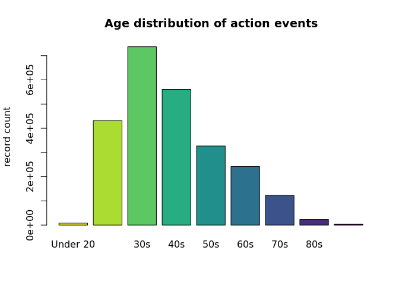

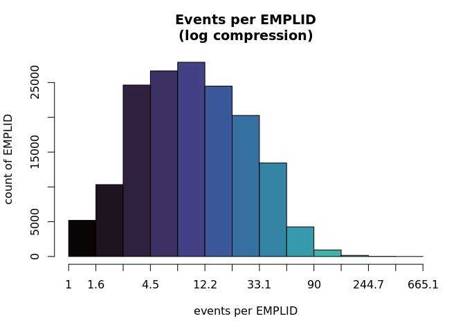

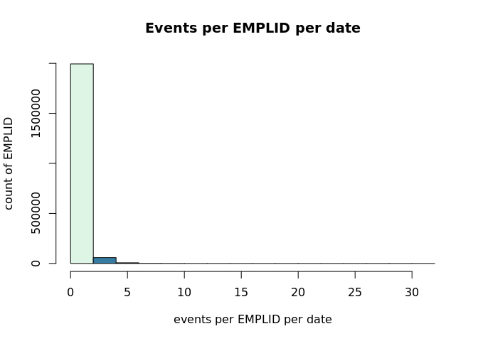

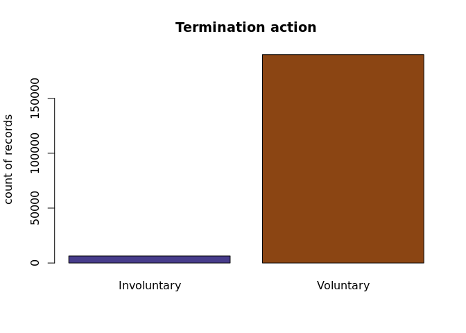

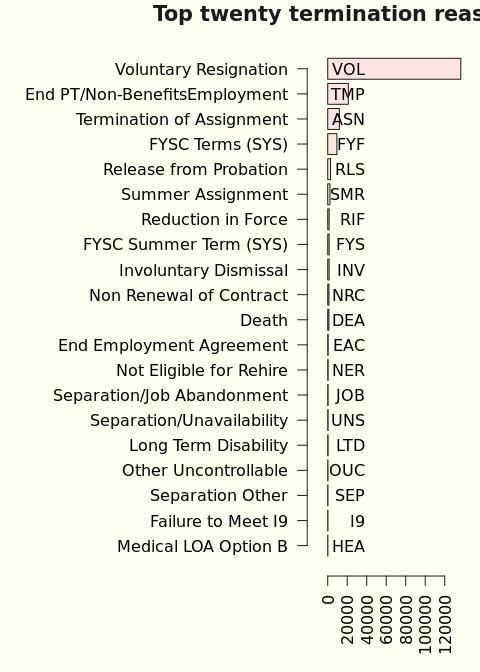

### Count of actions per date

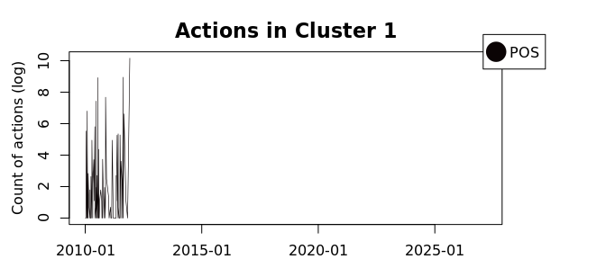

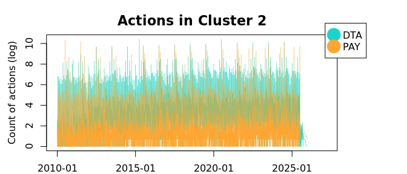

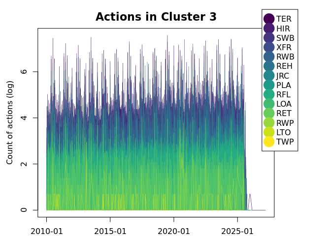

### Seasonality

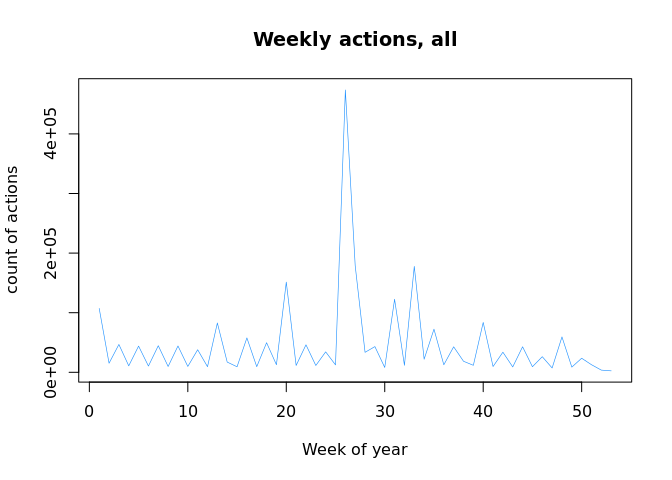

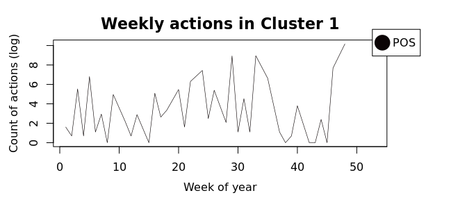

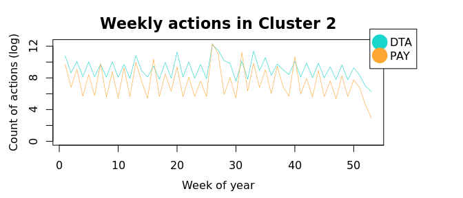

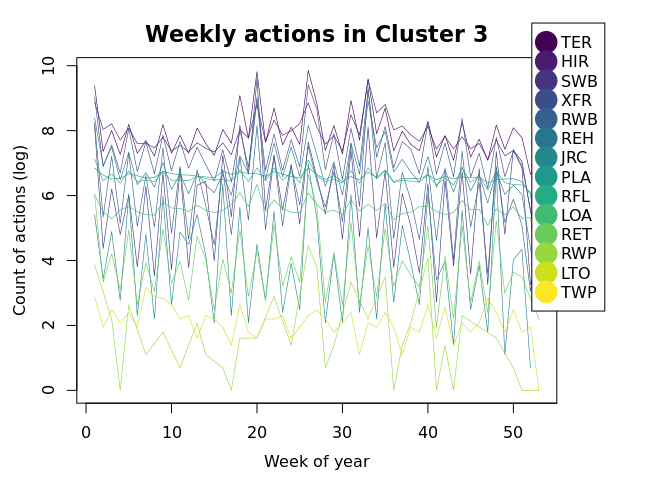

## (2) DEFINE “BOUNDARY” ACTIONS AND CHECK FOR INTERNAL CONSISTENCY

The actions and action reasons are reviewed, and grouped according to three main boundary types: primary, leave, and break.

These are then tallied per EMPLID to check for inconsistencies. In particular, the number of exits should never exceed the number of entries for a type, and the number of entries should never be greater than one more than the number of exits.

Many inconsistencies were found, suggesting additional processing and refinement of the “boundary” definitions.

For example:

- EMPLID “00028879” on EFFDT == “2010-01-16” shows identical rows except for the EMPL_RCD field.
- EMPLID “00029479” on EFFDT == “2011-07-16” show them returning from leave twice, were terminated, and transferred all in one day (and the employment records continue until they retired in 2022.)
- EMPLID “00002624” on EFFDT == “2021-03-16” added a “Hire Concurrent Job”, which suggests I should not consider this action as a boundary action.

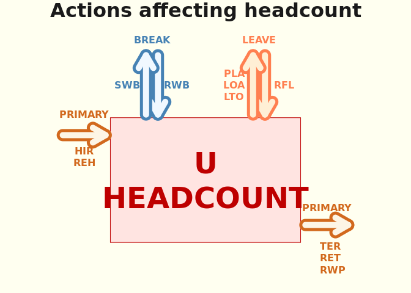

Too many exits

|  | count of EMPLID’s |
| --- | --- |
| break | 2021 |
| leave | 9122 |
| primary | 23304 |

Sample of EMPLIDs with more ‘break’ exits than entries

| EMPLID | entry | exit |
| --- | --- | --- |
| 00002679 | 15 | 16 |
| 00018782 | 1 | 3 |
| 00020008 | 2 | 4 |
| 00020291 | 3 | 4 |
| 00029763 | 26 | 27 |
| 00030805 | 8 | 9 |
| 00032475 | 33 | 34 |
| 00032484 | 1 | 2 |
| 00032643 | 6 | 7 |
| 00032890 | 8 | 9 |

Sample of EMPLIDs with more ‘leave’ exits than entries

| EMPLID | entry | exit |
| --- | --- | --- |
| 00000133 | 1 | 2 |
| 00000441 | 1 | 5 |
| 00000750 | 1 | 2 |
| 00000880 | 0 | 1 |
| 00001233 | 1 | 2 |
| 00001756 | 1 | 3 |
| 00002040 | 1 | 2 |
| 00002760 | 1 | 2 |
| 00002908 | 1 | 3 |
| 00003188 | 4 | 5 |

Sample of EMPLIDs with more ‘primary’ exits than entries

| EMPLID | entry | exit |
| --- | --- | --- |
| 00000008 | 0 | 1 |
| 00000395 | 1 | 3 |
| 00000396 | 0 | 1 |
| 00000496 | 0 | 1 |
| 00000519 | 0 | 1 |
| 00000579 | 0 | 2 |
| 00000965 | 0 | 1 |
| 00001007 | 1 | 2 |
| 00001072 | 0 | 1 |
| 00001211 | 0 | 1 |

Too many entries

|  | count of EMPLID’s |
| --- | --- |
| break | 59 |
| leave | 11 |
| primary | 3331 |

More ‘break’ entries than exits

| EMPLID | entry | exit |
| --- | --- | --- |
| 00028441 | 16 | 14 |
| 00028879 | 2 | 0 |
| 00029116 | 36 | 34 |
| 00031054 | 31 | 29 |
| 00031446 | 13 | 11 |
| 00031770 | 3 | 1 |
| 00032225 | 2 | 0 |
| 00032344 | 24 | 22 |
| 00033357 | 8 | 6 |
| 00034040 | 53 | 51 |

More ‘leave’ entries than exits

| EMPLID | entry | exit |
| --- | --- | --- |
| 00028642 | 2 | 0 |
| 00029479 | 2 | 0 |
| 00030202 | 8 | 6 |
| 00031663 | 2 | 0 |
| 00033446 | 2 | 0 |
| 00050411 | 12 | 10 |
| 00123962 | 3 | 1 |
| 00417534 | 2 | 0 |
| 00532825 | 2 | 0 |
| 00556762 | 2 | 0 |

More ‘primary’ entries than exits

| EMPLID | entry | exit |
| --- | --- | --- |
| 00000505 | 2 | 0 |
| 00000611 | 2 | 0 |
| 00000834 | 2 | 0 |
| 00001325 | 2 | 0 |
| 00002624 | 3 | 1 |
| 00003232 | 2 | 0 |
| 00004503 | 2 | 0 |
| 00005299 | 2 | 0 |
| 00005784 | 2 | 0 |
| 00005964 | 2 | 0 |

### Investigating “EMPL_RCD” field

Out of 2,060,674 dates per EMPLID, some 290,419 (14)% have multiple values for the “EMPL_RCD” field. Of these, 56,403 (19)% are otherwise identical in every field except for “EMPL_RCD”.

### Query

The query below is converted to a view, ds_hr.EMPL_AGE_RANGE_ACTION_MV_V.

“SELECT A.EMPLID, A.EMPL_RCD, A.EFFDT, A.EFFSEQ , A.ACTION, B.ACTION_DESCR , A.ACTION_REASON, C.DESCR ACTION_REASON_DESCR , Case when A.ACTION ! = ‘TER’ then ’’ when A.ACTION = (‘TER’) AND A.ACTION_REASON not in (‘BNK’, ‘EVW’, ‘I9’, ‘INV’, ‘NER’, ‘RFN’, ‘RIF’, ‘RLS’) then ‘Voluntary’ else ‘Involuntary’ end VOLUNTARY_FLAG , Case when (SYSDATE-D.BIRTHDATE)/365.25 < 20 then ‘Under 20’ when (SYSDATE-D.BIRTHDATE)/365.25 >= 20 and (SYSDATE-D.BIRTHDATE)/365.25 < 30 then ‘20s’ when (SYSDATE-D.BIRTHDATE)/365.25 >= 30 and (SYSDATE-D.BIRTHDATE)/365.25 < 40 then ‘30s’ when (SYSDATE-D.BIRTHDATE)/365.25 >= 40 and (SYSDATE-D.BIRTHDATE)/365.25 < 50 then ‘40s’ when (SYSDATE-D.BIRTHDATE)/365.25 >= 50 and (SYSDATE-D.BIRTHDATE)/365.25 < 60 then ‘50s’ when (SYSDATE-D.BIRTHDATE)/365.25 >= 60 and (SYSDATE-D.BIRTHDATE)/365.25 < 70 then ‘60s’ when (SYSDATE-D.BIRTHDATE)/365.25 >= 70 and (SYSDATE-D.BIRTHDATE)/365.25 < 80 then ‘70s’ when (SYSDATE-D.BIRTHDATE)/365.25 >= 80 and (SYSDATE-D.BIRTHDATE)/365.25 < 90 then ‘80s’ else ‘90 and Above’ end Age_Band

FROM PS_UU_UNSEC_JOB_VW A JOIN PS_ACTION_TBL B ON (B.ACTION = A.ACTION AND B.EFFDT = (SELECT MAX(B_ED.EFFDT) FROM PS_ACTION_TBL B_ED WHERE B.ACTION = B_ED.ACTION AND B_ED.EFFDT <= SYSDATE)) JOIN PS_ACTN_REASON_TBL C ON (C.ACTION = A.ACTION AND C.ACTION_REASON = A.ACTION_REASON AND C.EFFDT = (SELECT MAX(C_ED.EFFDT) FROM PS_ACTN_REASON_TBL C_ED WHERE C.ACTION = C_ED.ACTION AND C.ACTION_REASON = C_ED.ACTION_REASON AND C_ED.EFFDT <= SYSDATE)) JOIN ps_personal_dt_fst D ON (D.EMPLID = A.EMPLID)

WHERE A.EFFDT > TO_DATE(‘2010-01-01’,‘YYYY-MM-DD’) ORDER BY A.EMPLID, A.EMPL_RCD, A.EFFDT”